# Life Science and Device Intel

**Week of September 14, 2026**Market data through: September 11, 2026Narrative created: September 14, 2026

Weekly review of pharmaceutical, biotech, biologics, and medical-device company performance, changes, earnings activity, and strategy narrative.

## In the News

### Executive View

- **Del-desiran’s Phase 3 failure materially weakens both Novartis’s $12 billion Avidity acquisition thesis and confidence in extrapolating muscle RNA knockdown into functional benefit.** The miss does not invalidate antibody-oligonucleotide conjugates, but undisclosed secondary results provide no credible basis yet for regulatory salvage.
- **Amgen’s Imdelltra crossed into first-line small-cell lung cancer.** The DLL3 T-cell engager improved overall survival as maintenance after chemo-immunotherapy, potentially extending treatment to patients who would never reach second line; undisclosed effect sizes remain the critical limitation.
- **FDA established muscle-directed therapy as a new layer of spinal muscular atrophy treatment.** Isembyld’s approval creates an add-on market for residual weakness despite SMN2-targeted therapy, although the benefit is moderate, treatment requires monthly infusions and fractures warrant monitoring.
- **Convenience is becoming a credible source of clinical differentiation in hereditary angioedema.** Once-daily deucrictibant produced an 83% placebo-adjusted reduction in attacks, potentially allowing Pharvaris to offer oral on-demand and preventive formulations within one franchise.
- **Pediatric obesity treatment moved materially earlier.** Semaglutide moved 40% of treated children aged 6–11 below the obesity threshold, but Novo Nordisk has not yet disclosed the primary mean BMI effect, discontinuation data or full safety results.

### Strategy Narrative

#### Del-desiran turns Novartis’s Avidity bet into an endpoint and platform-reproducibility problem

**What changed**

On September 8, Novartis reported that the approximately 150-patient Phase 3 HARBOR trial in myotonic dystrophy type 1 failed to improve video hand-opening time versus placebo after 54 weeks. The company reported unspecified “clinical activity” on secondary and exploratory measures but disclosed no effect sizes. Safety was generally consistent with prior studies. ([Novartis](https://www.novartis.com/us-en/news/media-releases/novartis-provides-update-delpacibart-etedesiran-del-desiran-phase-iii-harbor-study-treatment-myotonic-dystrophy-type-1-dm1); [SEC filing](https://www.sec.gov/Archives/edgar/data/1114448/000117184326005908/f6k_090826.htm)) ([novartis.com](https://www.novartis.com/us-en/news/media-releases/novartis-provides-update-delpacibart-etedesiran-del-desiran-phase-iii-harbor-study-treatment-myotonic-dystrophy-type-1-dm1?utm_source=openai))

**What it tells us**

This extends last Monday’s emphasis on functional evidence over target engagement. Earlier del-desiran studies demonstrated delivery into muscle and DMPK-mRNA reduction, but HARBOR did not convert that biology into success on its prespecified pivotal endpoint. Because video hand-opening time is a novel measure focused on myotonia rather than overall disability, endpoint selection may have contributed; however, absent quantitative results for grip strength, DM1-Activ, muscle testing and mobility, the program should be valued as failed rather than merely delayed.

The commercial impact is broader than one rare-disease asset. Del-desiran was the most advanced validation opportunity within Novartis’s $12 billion acquisition of Avidity. The failure therefore reduces the acquisition’s risk-adjusted value and raises the evidentiary bar for sister programs del-zota in Duchenne muscular dystrophy and del-brax in facioscapulohumeral muscular dystrophy. It does not establish a class failure because those programs use different oligonucleotide payloads and address different biology. ([fiercebiotech.com](https://www.fiercebiotech.com/biotech/novartis-centerpiece-12b-avidity-buyout-flunks-crucial-phase-3-test?utm_source=openai))

**What to watch next**

The complete secondary-endpoint dataset; whether FDA entertains an alternative development path; and whether Novartis changes the regulatory or commercial assumptions for del-zota and del-brax.

#### Imdelltra could move T-cell engagement into routine first-line SCLC maintenance

**What changed**

Amgen’s 563-patient Phase 3 DeLLphi-305 trial met its overall-survival endpoint at a prespecified interim analysis. Imdelltra plus durvalumab also improved progression-free survival and response rate versus durvalumab alone in patients whose extensive-stage small-cell lung cancer had not progressed after durvalumab, platinum chemotherapy and etoposide. No efficacy magnitudes were disclosed. The company reported no unexpected safety signal, with short monitoring periods required after the first two Imdelltra infusions. ([Amgen](https://www.amgen.com/newsroom/press-releases/2026/09/imdelltra-in-combination-with-imfinzi-demonstrated-landmark-improvement-in-overall-survival-in-first-line-extensive-stage-small-cell-lung-cancer)) (amgen.com)

**What it tells us**

Imdelltra previously demonstrated a major survival benefit after progression; DeLLphi-305 now suggests DLL3-directed T-cell engagement can improve outcomes before relapse. That is strategically important in SCLC because many patients deteriorate too quickly to receive later-line therapy.

The trial also supports a sequencing model in which intensive chemo-immunotherapy induction is followed by immune maintenance escalation rather than additional cytotoxic therapy. Commercial value will depend on whether the survival gain justifies chronic infusion, early cytokine-release and neurologic-risk management, and the added cost of combining two branded immunotherapies.

**What to watch next**

Median survival, hazard ratios, treatment discontinuations, grade 3/4 infections and cytokine-release syndrome—and whether benefit extends across patients with brain metastases.

#### Isembyld establishes combination treatment for residual SMA disability

**What changed**

FDA approved Scholar Rock’s Isembyld, or apitegromab, for adults and children aged two and older receiving an SMN2-targeted treatment. In the controlled SAPPHIRE trial, monthly 10 mg/kg infusions produced a 2.2-point placebo-adjusted improvement on the Hammersmith motor scale; 34.2% achieved a clinically meaningful three-point improvement versus 13.5% with placebo. The strongest controlled evidence came from nonambulatory children aged 2–12. FDA highlighted an increased fracture risk. ([FDA](https://www.fda.gov/drugs/news-events-human-drugs/fda-approves-first-therapy-target-muscle-loss-spinal-muscular-atrophy); [Scholar Rock](https://investors.scholarrock.com/news-releases/news-release-details/scholar-rock-announces-fda-approval-isembyldtm-apitegromab-mstn)) ([fda.gov](https://www.fda.gov/drugs/news-events-human-drugs/fda-approves-first-therapy-target-muscle-loss-spinal-muscular-atrophy?utm_source=openai))

**What it tells us**

SMA is shifting from replacement of missing SMN protein toward multidimensional combination care. Isembyld does not compete directly with Spinraza, Evrysdi or gene replacement; it addresses persistent muscle weakness after motor-neuron rescue.

The mean benefit is meaningful but not transformative, and monthly intravenous administration adds substantial burden. Commercial adoption is therefore likely to concentrate initially among patients who remain functionally impaired despite stable SMN-directed treatment. Payers may demand documented plateau or decline before authorizing an indefinite add-on biologic.

**What to watch next**

Adult uptake, ambulatory evidence, durability beyond one year, fracture incidence and whether muscle-directed treatment expands to other neuromuscular diseases.

#### Oral prophylaxis and earlier obesity treatment expand chronic-therapy frontiers

Pharvaris’s 85-patient Phase 3 CHAPTER-3 trial showed an 83% reduction in hereditary-angioedema attacks versus placebo with once-daily deucrictibant XR; the reduction was 87% among type 1 and type 2 patients. No treatment-related serious adverse events were reported. The result is compelling but based on a small, 24-week trial, and absolute attack rates have not been disclosed—making cross-trial comparisons with injectable prophylactics premature. If confirmed, the immediate- and extended-release formulations could give Pharvaris a differentiated oral franchise spanning rescue and prevention. ([Pharvaris](https://ir.pharvaris.com/news-releases/news-release-details/pharvaris-announces-positive-topline-data-chapter-3-pivotal)) ([ir.pharvaris.com](https://ir.pharvaris.com/news-releases/news-release-details/pharvaris-announces-positive-topline-data-chapter-3-pivotal))

Separately, Novo Nordisk reported that 40.4% of children aged 6–11 receiving semaglutide plus lifestyle intervention were no longer classified as having obesity after 68 weeks, versus none on placebo. More than 85% had severe obesity at baseline, and no growth or pubertal-development signal was identified. The finding strengthens medical treatment of severe pediatric obesity, but the withheld mean BMI result, treatment-estimand framing and need for long-term therapy limit interpretation until presentation at ObesityWeek in November. ([Novo Nordisk](https://www.novonordisk.com/news-and-media/news-and-ir-materials/news-details.html?id=916600)) ([novonordisk.com](https://www.novonordisk.com/news-and-media/news-and-ir-materials/news-details.html?id=916600))

### Additional Company and Regulatory Signals

- **Biohaven’s epilepsy licensing thesis acquired a toxicology overhang.** FDA paused new enrollment in BHV-7000 trials because available data were insufficient to assess the human risk of a metabolite found during rodent testing. More than 600 randomized patients may continue dosing, and one pivotal focal-epilepsy trial is fully enrolled, preserving the planned second-half readout. SK Biopharmaceuticals had received the underlying data before signing its licensing agreement, reducing transaction-surprise risk but not eventual approval risk. ([SEC filing](https://www.sec.gov/Archives/edgar/data/1935979/000193597926000077/bhvn-20260904.htm)) ([sec.gov](https://www.sec.gov/Archives/edgar/data/1935979/000193597926000077/bhvn-20260904.htm?utm_source=openai))
- **HER2-mutant lung cancer gained a second first-line targeted option.** FDA expanded Bayer’s Hyrnuo to untreated advanced disease after a single-arm study produced a 75% response rate; 38% of responders remained in response for at least 12 months. The accelerated approval creates direct competition with already-approved zongertinib, but comparative durability and toxicity—not response rate alone—will determine sequencing. ([FDA](https://www.fda.gov/drugs/resources-information-approved-drugs/fda-grants-accelerated-approval-sevabertinib-locally-advanced-or-metastatic-non-squamous-non-small)) ([fda.gov](https://www.fda.gov/drugs/resources-information-approved-drugs/fda-grants-accelerated-approval-sevabertinib-locally-advanced-or-metastatic-non-squamous-non-small))
- **FDA codified a lower-friction pathway for cardiovascular AI alerts.** A final order effective September 11 classified machine-learning notification software as Class II, allowing future substantially equivalent products to use the 510(k) pathway. Special controls explicitly address clinical performance, model bias and generalizability, human factors and overreliance. The likely strategic effect is faster category expansion—and greater commoditization of stand-alone alerts—shifting differentiation toward proprietary data, workflow integration and demonstrated impact on downstream care. ([Federal Register](https://www.govinfo.gov/content/pkg/FR-2026-09-11/pdf/FR-2026-09-11.pdf)) ([govinfo.gov](https://www.govinfo.gov/content/pkg/FR-2026-09-11/pdf/FR-2026-09-11.pdf?utm_source=openai))

### What I’m Watching Next

- Quantitative HARBOR secondary endpoints and implications for the remaining Avidity-derived programs.
- Full DeLLphi-305 survival and safety data.
- Real-world payer criteria and adoption for Isembyld combination therapy.
- Absolute attack rates and longer-term safety for deucrictibant.
- Detailed STEP Young BMI, discontinuation and post-treatment data.
- The fully enrolled BHV-7000 pivotal readout despite the partial clinical hold.

### Bottom Line

This week again separated biological activity from clinically and commercially usable benefit. Del-desiran reduced disease-associated RNA in earlier studies but failed its pivotal functional test. Imdelltra, by contrast, extended a proven mechanism into an earlier and larger treatment setting, while Isembyld converted a moderate motor benefit into an entirely new combination layer for SMA.

The strategic premium is increasingly accruing to therapies that do more than engage biology: they must choose defensible endpoints, fit into existing treatment sequences and offer sufficient efficacy or convenience to justify chronic cost and operational burden.

## Notable Changes

Comparison with the final report dated September 7, 2026 (market data through September 4, 2026).

### Sectors

#### Top-three comparison

| Entity | Previous | Current | Change | Current return |
| --- | --- | --- | --- | --- |
| Emerging Biotech | #1 | #1 | — 0 | +59.5% |
| Established Biotech | #2 | #2 | — 0 | +42.7% |
| Big Pharma | #3 | #3 | — 0 | +32.8% |

### Stocks

#### Top-three comparison

| Entity | Previous | Current | Change | Current return |
| --- | --- | --- | --- | --- |
| Moderna (MRNA) | #1 | #1 | — 0 | +512.4% |
| Krystal Biotech (KRYS) | #2 | #2 | — 0 | +141.5% |
| CG Oncology (CGON) | #3 | #3 | — 0 | +117.0% |

#### Largest rank changes

| Entity | Previous | Current | Change | Current return |
| --- | --- | --- | --- | --- |
| Novartis (NVS) | #21 | #29 | ↓ 8 | +10.5% |
| Inspire Medical Systems (INSP) | #48 | #35 | ↑ 13 | -8.8% |
| Transmedics (TMDX) | #40 | #47 | ↓ 7 | -28.3% |

### Subcategory movement since the previous report

| Subcategory | Move | Last Report, 12m Ret | Current Report, 12m Ret |
| --- | --- | --- | --- |
| Emerging Biotech | -2.7% | +61.3% | +59.5% |
| Big Pharma | -3.9% | +38.9% | +32.8% |
| Devices & Diagnostic | -5.4% | -16.2% | -19.3% |
| Established Biotech | -6.8% | +50.2% | +42.7% |

### Largest company moves

| Direction | Company | Ticker | Move |
| --- | --- | --- | --- |
| Gain | Inspire Medical Systems | INSP | +15.7% |
| Gain | United Therapeutics | UTHR | +1.9% |
| Gain | Corcept Therapeutics | CORT | +1.0% |
| Decline | Avidity Biosciences | RNA | -27.0% |
| Decline | Novartis | NVS | -14.3% |
| Decline | Amgen | AMGN | -13.7% |

## Subcategory Performance

| Subcategory | Companies | Market cap | 3m Return | 12m Return | 24m Return |
| --- | --- | --- | --- | --- | --- |
| Devices & Diagnostic | 17 | $839.9B | +1.9% | -19.3% | -15.1% |
| Big Pharma | 12 | $3.6T | +3.3% | +32.8% | +20.8% |
| Established Biotech | 15 | $813.7B | +15.6% | +42.7% | +31.5% |
| Emerging Biotech | 10 | $56.3B | +17.2% | +59.5% | +118.3% |

Subcategory returns use the most recently saved market capitalizations as weights.

## Stock Performance vs. SPY

The same selected stocks appear in every chart. Each line is labeled at the right with its ticker and return for the displayed window.

### Last 6 months

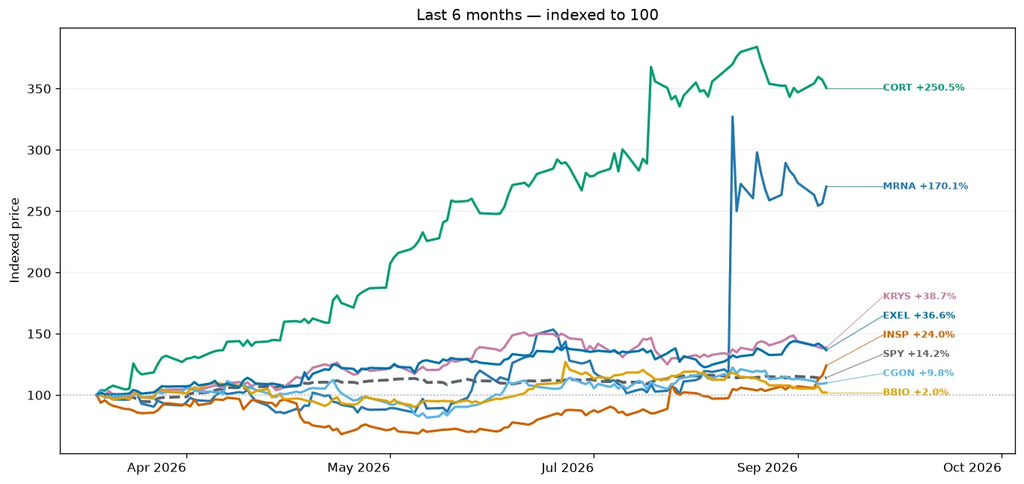

### Last 12 months

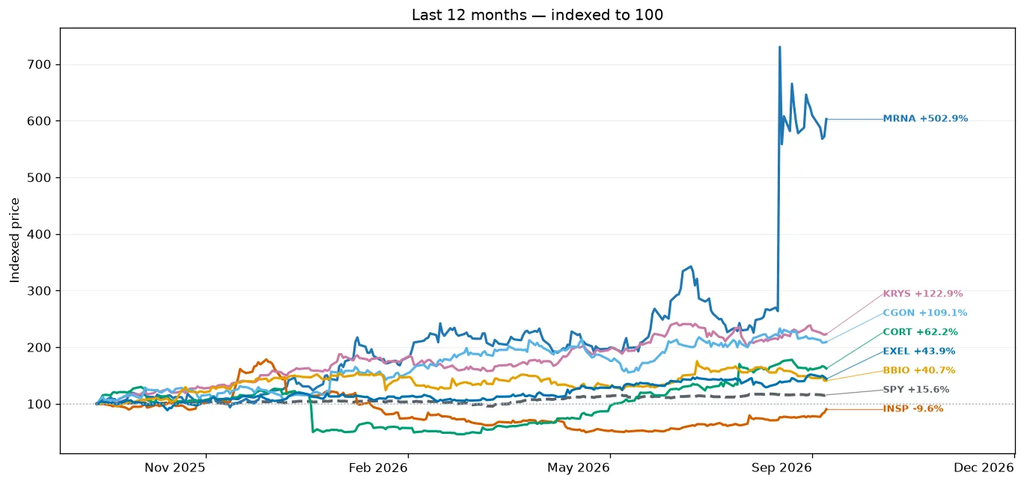

### Last 24 months

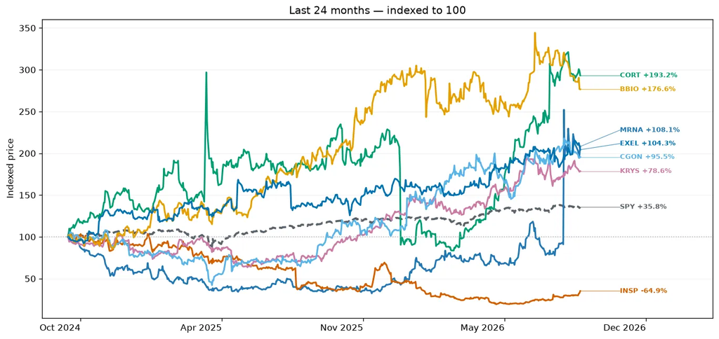

## Current Top Stocks

### Last 3 months

| Rank | Company | Ticker | Market cap | Return |
| --- | --- | --- | --- | --- |
| 1 | Moderna | MRNA | $22.8B | +188.5% |
| 2 | Inspire Medical Systems | INSP | $1.9B | +71.0% |
| 3 | Corcept Therapeutics | CORT | $11.9B | +36.0% |
| 4 | Sarepta | SRPT | $1.7B | +33.6% |
| 5 | Acadia Pharmaceuticals | ACAD | $4.6B | +32.0% |

### Last 12 months

| Rank | Company | Ticker | Market cap | Return |
| --- | --- | --- | --- | --- |
| 1 | Moderna | MRNA | $22.8B | +512.4% |
| 2 | Krystal Biotech | KRYS | $9.6B | +141.5% |
| 3 | CG Oncology | CGON | $6.3B | +117.0% |
| 4 | Merck | MRK | $316.1B | +73.8% |
| 5 | Viatris | VTRS | $20.6B | +65.8% |

### Last 24 months

| Rank | Company | Ticker | Market cap | Return |
| --- | --- | --- | --- | --- |
| 1 | Corcept Therapeutics | CORT | $11.9B | +196.0% |
| 2 | BridgeBio Pharma | BBIO | $16.1B | +176.7% |
| 3 | Exelixis | EXEL | $14.1B | +112.1% |
| 4 | Moderna | MRNA | $22.8B | +110.9% |
| 5 | CG Oncology | CGON | $6.3B | +107.9% |

## Companies by Subcategory

### Devices & DiagnosticLast 3m: +1.9%

| Company | Ticker | Market cap | 3m Return | 12m Return | 24m Return |
| --- | --- | --- | --- | --- | --- |
| Medtronic | MDT | $110.3B | +13.4% | -3.3% | +1.1% |
| Boston Scientific | BSX | $71.1B | -8.4% | -58.2% | -48.4% |
| Stryker | SYK | $128.9B | -11.7% | -28.1% | -25.6% |
| Zimmer Biomet | ZBH | $18.5B | +5.6% | -9.3% | -12.0% |
| Abbott | ABT | $182.5B | +15.6% | -23.8% | -12.4% |
| Becton Dickinson | BD | n/a | — | — | — |
| Edwards LifeSciences | EW | $51.6B | -0.9% | +8.8% | +23.1% |
| Dexcom | DXCM | $32.8B | +10.2% | +8.9% | +19.5% |
| ResMed | RMD | $32.4B | +12.1% | -19.2% | -12.3% |
| Insulet | PODD | $11.6B | -11.9% | -61.4% | -43.6% |
| Globus Medical | GMED | $11.1B | -7.7% | +26.3% | +6.4% |
| Intuitive Surgical | ISRG | $130.1B | -10.2% | -17.9% | -24.6% |
| GE Healthcare | GEHC | $31.7B | -1.9% | -16.4% | -26.4% |
| Transmedics | TMDX | $2.8B | +12.7% | -28.3% | -45.7% |
| STERIS | STE | $22.7B | +1.5% | -15.7% | -13.9% |
| Masimo | MASI | n/a | +0.0% | +22.0% | +59.5% |
| Inspire Medical Systems | INSP | $1.9B | +71.0% | -8.8% | -64.2% |

### Big PharmaLast 3m: +3.3%

| Company | Ticker | Market cap | 3m Return | 12m Return | 24m Return |
| --- | --- | --- | --- | --- | --- |
| Eli Lilly | LLY | $1.0T | -1.5% | +47.7% | +20.8% |
| Novo Nordisk | NVO | $195.8B | -1.8% | -21.5% | -68.6% |
| AbbVie | ABBV | $430.8B | +12.9% | +17.8% | +32.4% |
| Johnson & Johnson | JNJ | $614.4B | +10.3% | +49.2% | +60.5% |
| Pfizer | PFE | $144.8B | +5.8% | +16.1% | -5.3% |
| Merck | MRK | $316.1B | +20.9% | +73.8% | +24.2% |
| Bristol Myers Squibb | BMY | $134.6B | +11.4% | +37.7% | +29.5% |
| Viatris | VTRS | $20.6B | +0.2% | +65.8% | +41.6% |
| AstraZeneca | AZN | $241.3B | -10.4% | +0.7% | +2.3% |
| Novartis | NVS | $291.3B | -10.4% | +10.5% | +18.6% |
| Sanofi | SNY | $103.6B | -3.3% | -9.1% | -25.1% |
| GSK | GSK | $103.2B | -9.3% | +17.9% | +11.9% |

### Established BiotechLast 3m: +15.6%

[output not shown]

### Emerging BiotechLast 3m: +17.2%

| Company | Ticker | Market cap | 3m Return | 12m Return | 24m Return |
| --- | --- | --- | --- | --- | --- |
| ADMA Biologics | ADMA | $2.1B | +12.4% | -42.7% | -49.0% |
| Ocular therapeutix | OCUL | $1.9B | +17.3% | -18.1% | +16.6% |
| Novocure | NVCR | $1.9B | -12.8% | +27.7% | -16.5% |
| Corcept Therapeutics | CORT | $11.9B | +36.0% | +54.8% | +196.0% |
| Acadia Pharmaceuticals | ACAD | $4.6B | +32.0% | +17.9% | +70.5% |
| Krystal Biotech | KRYS | $9.6B | +9.1% | +141.5% | +72.1% |
| Avidity Biosciences | RNA | $197.4M | -16.2% | -76.8% | -75.2% |
| Recursion Pharmaceuticals | RXRX | $1.8B | +1.6% | -33.7% | -51.3% |
| CG Oncology | CGON | $6.3B | +21.5% | +117.0% | +107.9% |
| BridgeBio Pharma | BBIO | $16.1B | +8.4% | +41.5% | +176.7% |

## Upcoming Earnings

No saved earnings dates fall within the next seven days.

## Recent Earnings Highlights — 3m Ret

No earnings highlights fall within this report's window.

## Company Overviews

### Medtronic (MDT)

*Devices & Diagnostic · $110.3B · 3m +13.4% · 12m -3.3% · 24m +1.1%*

[Google Finance](https://www.google.com/finance/quote/MDT:NYSE?tab=earnings&hl=en)

Large medical device company with broad portfolio across cardiovascular, neuroscience, surgical, and diabetes care.

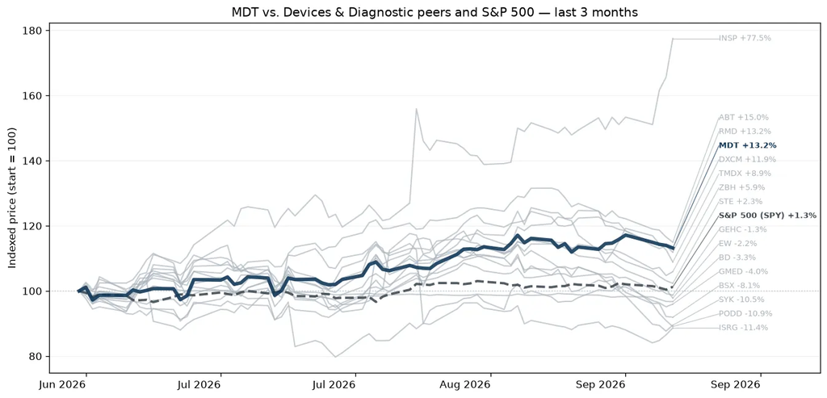

One of the largest medical-device companies, Medtronic develops and manufactures therapeutic medical devices for chronic diseases. Its portfolio includes pacemakers, defibrillators, transcatheter heart valves, stents, spinal fixation devices, neurovascular products, advanced energy, ablation laser therapy, and surgical tools. The company primarily markets its products to healthcare institutions and physicians in the United States, Western Europe, and Japan. Foreign sales account for roughly 50% of the company's total sales.

### Boston Scientific (BSX)

*Devices & Diagnostic · $71.1B · 3m -8.4% · 12m -58.2% · 24m -48.4%*

[Google Finance](https://www.google.com/finance/quote/BSX:NYSE?tab=earnings&hl=en)

Growth-focused medtech leader specializing in minimally invasive cardiovascular, electrophysiology, endoscopy, and neuromodulation devices.

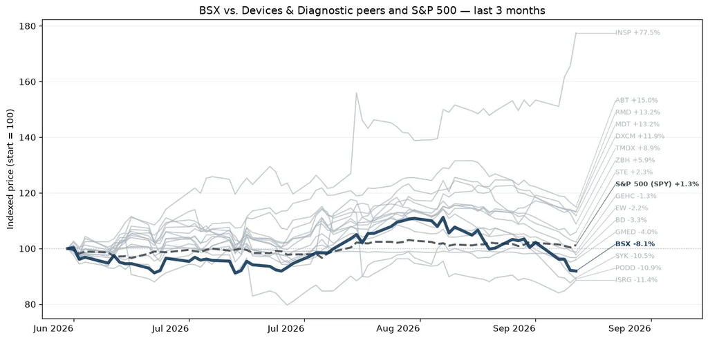

Boston Scientific focuses on less invasive medical devices that are inserted into the human body through small openings or cuts. It manufactures products for use in angioplasty, blood clot filtration, kidney stone management, cardiac rhythm management, catheter-directed ultrasound imaging, upper gastrointestinal tract diagnostics, interventional oncology, neuromodulation for chronic pain, and treatment of incontinence. The firm markets its devices to healthcare professionals and institutions globally. Foreign sales account for roughly 36% of the firm's total sales.

### Stryker (SYK)

*Devices & Diagnostic · $128.9B · 3m -11.7% · 12m -28.1% · 24m -25.6%*

[Google Finance](https://www.google.com/finance/quote/SYK:NYSE?tab=earnings&hl=en)

Premier orthopedic and surgical technology company best known for joint replacements, MedSurg equipment, and Mako robotic assisted surgery systems.

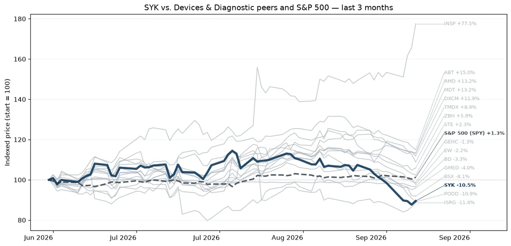

Stryker designs, manufactures, and markets an array of medical equipment, instruments, consumable supplies, and implantable devices. The product portfolio includes hip and knee replacements, extremities, endoscopy systems, operating room equipment, embolic coils, mechanical thrombectomy systems, hospital beds and gurneys, and orthopedic robotics. Stryker remains one of the three largest competitors in reconstructive orthopedic implants and holds the leadership position in operating room equipment. Roughly one-fourth of Stryker's total revenue currently comes from outside the United States.

### Zimmer Biomet (ZBH)

*Devices & Diagnostic · $18.5B · 3m +5.6% · 12m -9.3% · 24m -12.0%*

[Google Finance](https://www.google.com/finance/quote/ZBH:NYSE?tab=earnings&hl=en)

Orthopedic specialist centered on knee, hip, and extremity implants, with robotic surgery offerings for joint reconstruction.

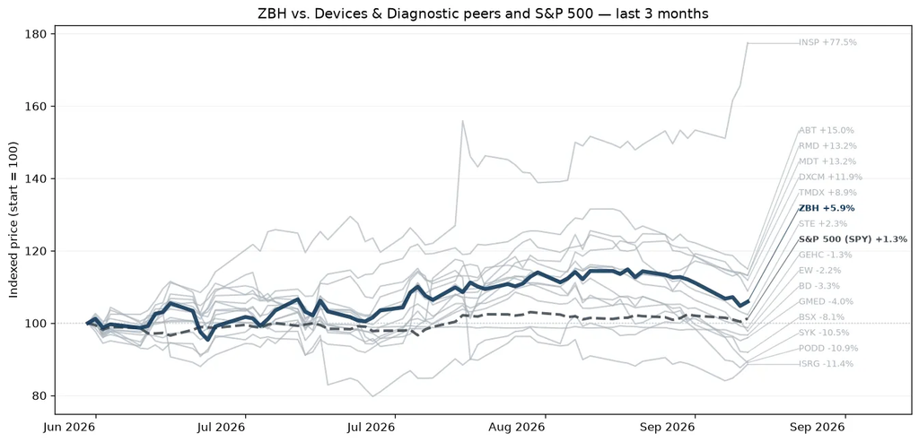

Zimmer Biomet designs, manufactures, and markets orthopedic reconstructive implants as well as supplies and surgical equipment for orthopedic surgery. With the acquisitions of Centerpulse in 2003 and Biomet in 2015, Zimmer holds the leading share of the reconstructive market in the United States, Europe, and Japan. Roughly two-thirds of total revenue is derived from sales of large joints; another fourth comes from extremities, trauma, sports medicine, and related surgical products. The firm spun out its dental and spine businesses in 2022.

### Abbott (ABT)

*Devices & Diagnostic · $182.5B · 3m +15.6% · 12m -23.8% · 24m -12.4%*

[Google Finance](https://www.google.com/finance/quote/ABT:NYSE?tab=earnings&hl=en)

Diversified healthcare company spanning diagnostics, medical devices, nutrition products, and established pharmaceuticals.

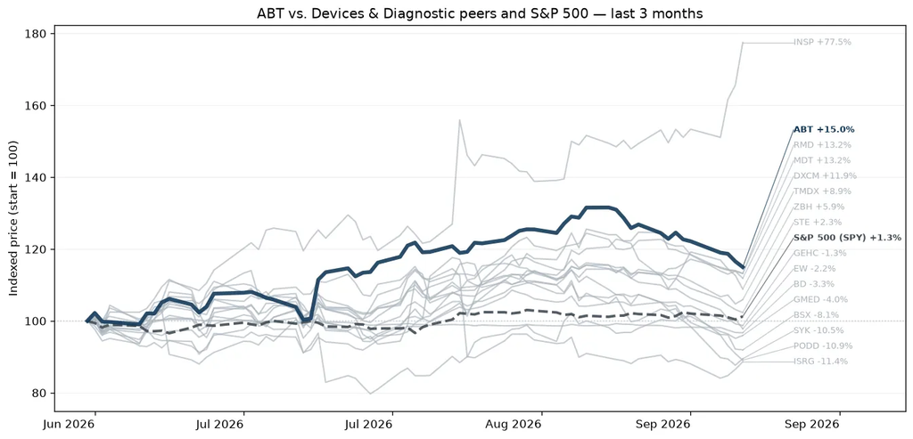

Abbott manufactures and markets cardiovascular and diabetes devices, adult and pediatric nutritional products, diagnostic equipment and testing kits, and branded generic drugs. Products include pacemakers, implantable cardioverter defibrillators, neuromodulation devices, coronary stents, catheters, infant formula, nutritional liquids for adults, continuous glucose monitors, and immunoassays and point-of-care diagnostic equipment. Abbott derives roughly 60% of sales outside the United States.

### Becton Dickinson (BD)

*Devices & Diagnostic · n/a · 3m n/a · 12m n/a · 24m n/a*

[Google Finance](https://www.google.com/finance/quote/BD:NYSEARCA?tab=earnings&hl=en)

leading medical product and component company.

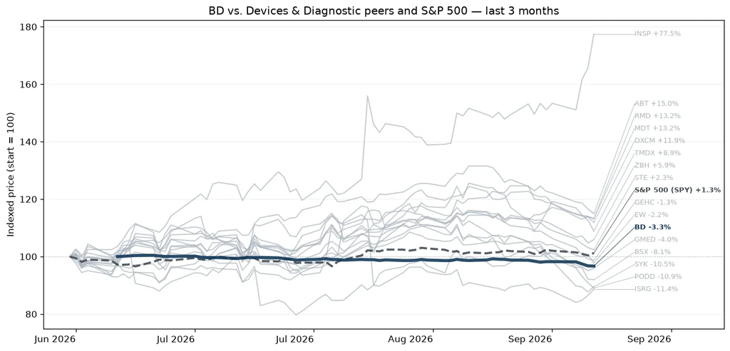

### Edwards LifeSciences (EW)

*Devices & Diagnostic · $51.6B · 3m -0.9% · 12m +8.8% · 24m +23.1%*

[Google Finance](https://www.google.com/finance/quote/EW:NYSE?tab=earnings&hl=en)

Cardiovascular company focused on structural heart therapies, particularly transcatheter and surgical heart valve tech.

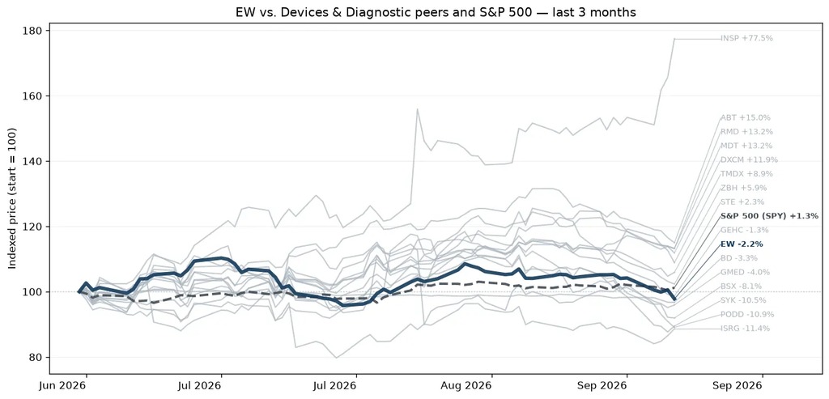

Spun off from Baxter International in 2000, Edwards Lifesciences designs, manufactures, and markets a range of medical devices and equipment for advanced stages of structural heart disease. It has established itself as a leader across key products, including surgical tissue heart valves, transcatheter aortic valves, and transcatheter mitral and tricuspid valve technologies. The firm derives about 60% of its total sales from outside the US.

### Dexcom (DXCM)

*Devices & Diagnostic · $32.8B · 3m +10.2% · 12m +8.9% · 24m +19.5%*

[Google Finance](https://www.google.com/finance/quote/DXCM:NASDAQ?tab=earnings&hl=en)

Leading independent continuous glucose monitoring company.

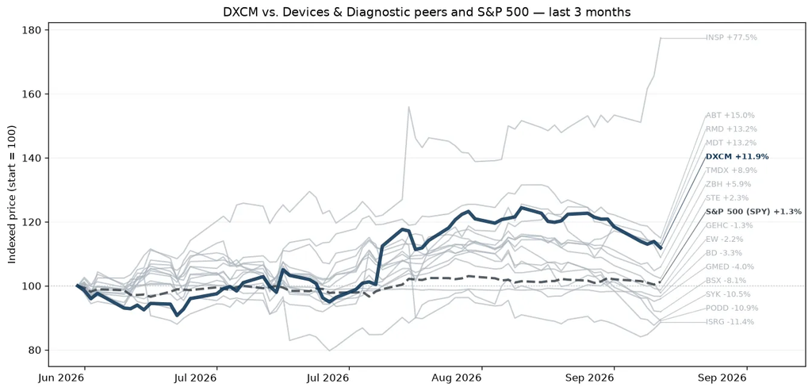

DexCom designs and commercializes continuous glucose monitoring systems for diabetic patients. CGM systems serve as an alternative to the traditional blood glucose meter process, and the company is evolving its CGM systems to provide integration with insulin pumps from Insulet and Tandem for automatic insulin delivery. DexCom's CGMs are available through medical equipment distributors as well as retail pharmacies.

### ResMed (RMD)

*Devices & Diagnostic · $32.4B · 3m +12.1% · 12m -19.2% · 24m -12.3%*

[Google Finance](https://www.google.com/finance/quote/RMD:NYSE?tab=earnings&hl=en)

Sleep and respiratory care known for CPAP devices, masks, and connected software for sleep apnea and respiratory disorders.

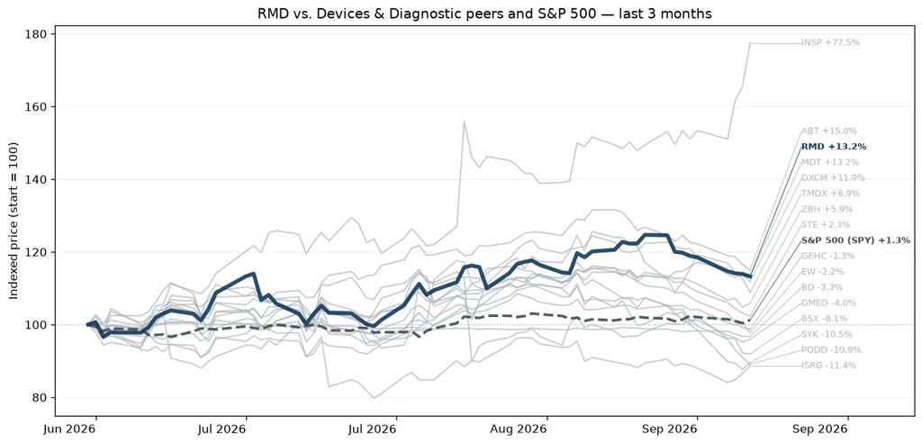

ResMed is one of the largest respiratory care device companies globally, primarily developing and supplying flow generators, masks, and accessories for the treatment of sleep apnea. Increasing diagnosis of sleep apnea combined with aging populations and increasing prevalence of obesity is resulting in a structurally growing market. The company earns roughly two-thirds of its revenue in the Americas and the balance across other regions dominated by Europe, Japan, and Australia. Recent developments and acquisitions have focused on digital health as ResMed is aiming to differentiate itself through the provision of clinical data for use by the patient, medical care advisor, and payer in the out-of-hospital setting.

### Insulet (PODD)

*Devices & Diagnostic · $11.6B · 3m -11.9% · 12m -61.4% · 24m -43.6%*

[Google Finance](https://www.google.com/finance/quote/PODD:NASDAQ?tab=earnings&hl=en)

Diabetes technology company whose Omnipod platform pioneered the tubeless wearable insulin pump market.

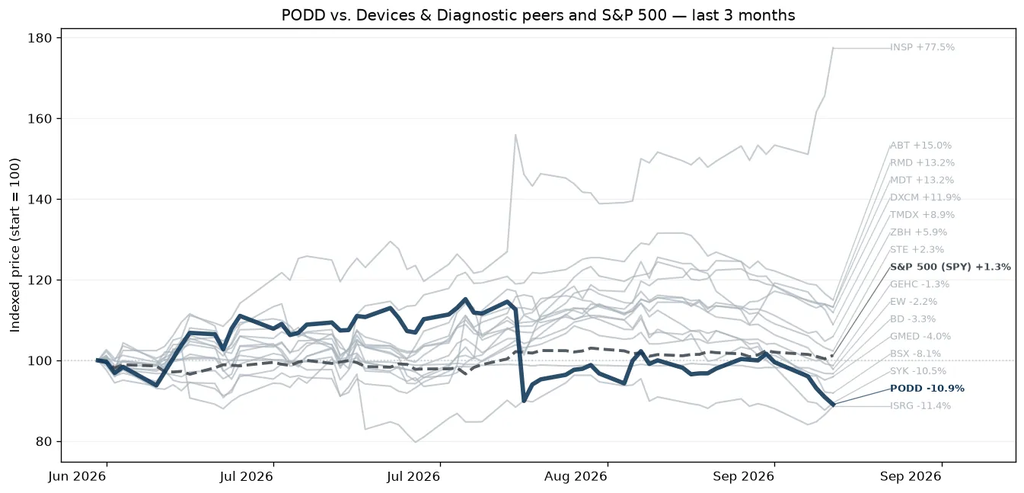

Insulet was founded in 2000 with the goal of making continuous subcutaneous insulin infusion therapy for diabetes easier to use. The result was the Omnipod system, which consists of a small disposable insulin infusion device that can be operated through a smartphone to control dosage. Since the Omnipod was approved by the US Food and Drug Administration in 2005, more than 600,000 insulin-dependent diabetic patients are using it worldwide.

### Globus Medical (GMED)

*Devices & Diagnostic · $11.1B · 3m -7.7% · 12m +26.3% · 24m +6.4%*

[Google Finance](https://www.google.com/finance/quote/GMED:NYSE?tab=earnings&hl=en)

Musculoskeletal device company focused on spine surgery, orthopedic trauma, and robotic navigation techniques.

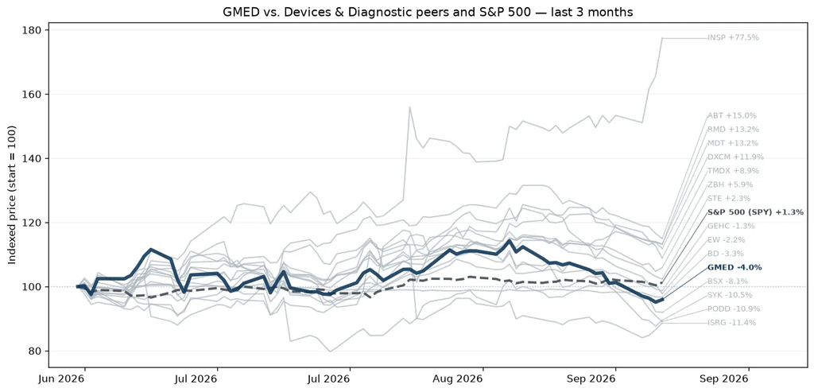

Globus Medical Inc is a medical device company that develops and provides healthcare products and solutions to hospitals, physicians, and surgical centers. The firm's products are organized into two categories: musculoskeletal solutions, which include medical devices and instruments used mostly for spinal and orthopedic procedures, and enabling technologies, which include computer systems developed for enhancing surgical capabilities. The vast majority of the company's revenue is generated from musculoskeletal solutions products, and more than half of the revenue is earned in the United States. It also has its presence internationally.

### Intuitive Surgical (ISRG)

*Devices & Diagnostic · $130.1B · 3m -10.2% · 12m -17.9% · 24m -24.6%*

[Google Finance](https://www.google.com/finance/quote/ISRG:NASDAQ?tab=earnings&hl=en)

Dominant robotic surgery company whose da Vinci systems have come the standard platform for many minimally invasive surgeries.

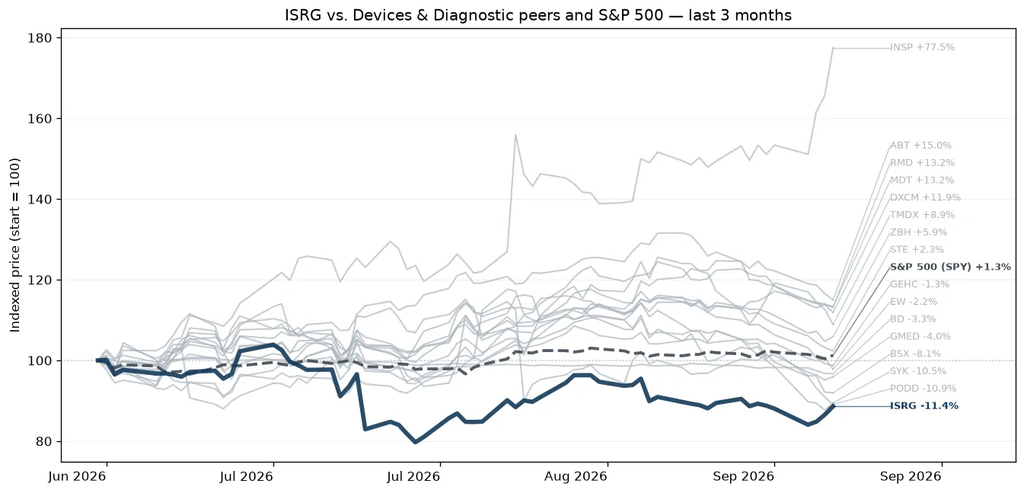

Intuitive develops, produces, and markets a robotic system for assisting minimally invasive surgery. It also provides the instrumentation, disposable accessories, and warranty services for the system. The company has placed more than 10,000 da Vinci systems in hospitals worldwide, with more than 6,000 installations in the US and a growing number in emerging markets.

### GE Healthcare (GEHC)

*Devices & Diagnostic · $31.7B · 3m -1.9% · 12m -16.4% · 24m -26.4%*

[Google Finance](https://www.google.com/finance/quote/GEHC:NASDAQ?tab=earnings&hl=en)

Medical technology & diagnostic company focused on imaging equipment, patient monitoring, ultrasound, and healthcare IT infrastructure.

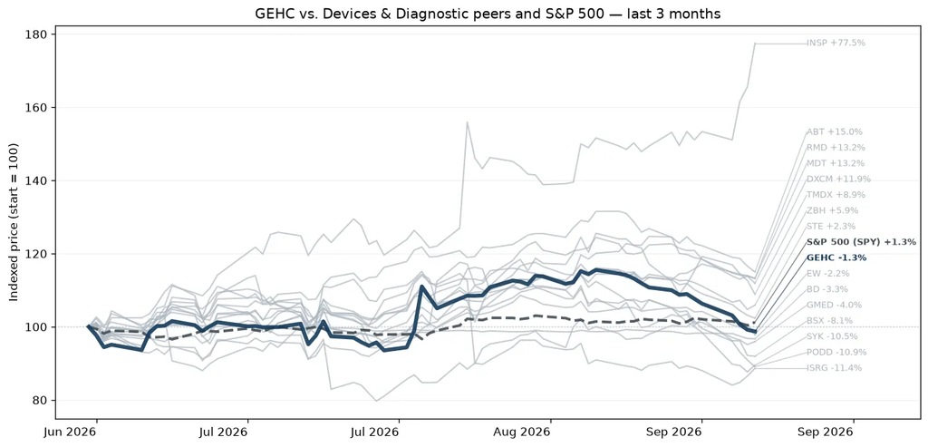

GE HealthCare Technologies is a leading medical technology firm with leading market share in imaging and ultrasound equipment. The company reports four major segments: imaging (45% of revenue), advanced visualization solutions (26%), patient care solutions (15%), and pharmaceutical diagnostics (14%). The company's sales are geographically diverse, with the United States, EMEA, China, and the rest of the world accounting for 46%, 26%, 11%, and 17%, respectively. We estimate approximately half of its revenue is recurring, which consists of servicing (about one-third of revenue), pharmaceutical diagnostics (about 10%-15%), and digital solutions (just over 5%).

### Transmedics (TMDX)

*Devices & Diagnostic · $2.8B · 3m +12.7% · 12m -28.3% · 24m -45.7%*

[Google Finance](https://www.google.com/finance/quote/TMDX:NASDAQ?tab=earnings&hl=en)

Transplant technology and transportation company whose Organ Care System keeps donor organs functioning outside the body, expanding organ supply.

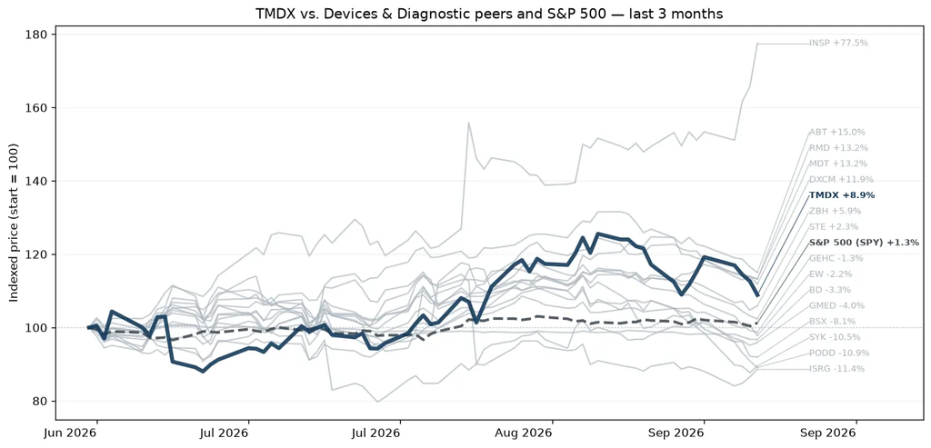

TransMedics Group Inc is a commercial-stage medical technology company transforming organ transplant therapy for end-stage organ failure patients across multiple disease states. It has developed the Organ Care System (OCS) to comprehensively address the limitations of cold storage. The OCS is a portable organ perfusion, optimization, and monitoring system that utilizes technology to replicate near-physiologic conditions for donor organs outside of the human body. The company has developed and is commercializing a proprietary system to preserve and deliver human organs for transplant in a near-physiologic condition to address the limitations of cold storage organ preservation.

### STERIS (STE)

*Devices & Diagnostic · $22.7B · 3m +1.5% · 12m -15.7% · 24m -13.9%*

[Google Finance](https://www.google.com/finance/quote/STE:NYSE?tab=earnings&hl=en)

provider of infection prevention, sterilization, and surgical support products and services.

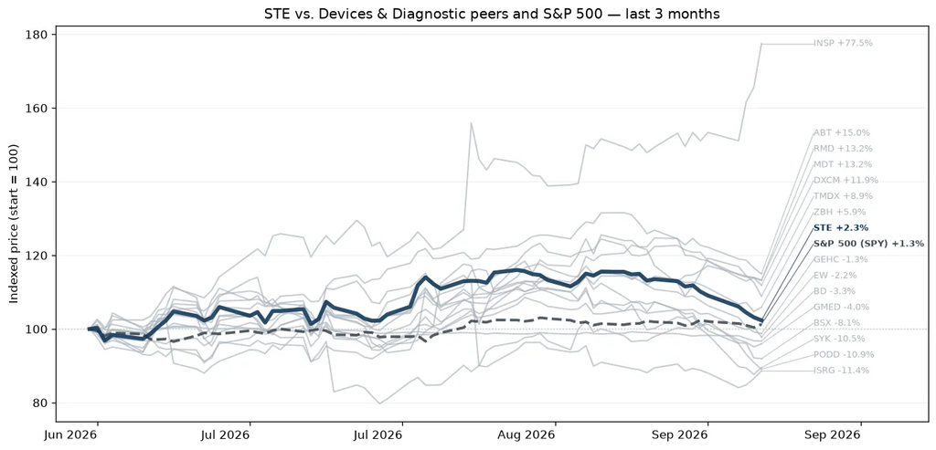

Steris is an Ireland-domiciled medical technology company focused on sterilization services and infection prevention. The company is the global leader in contract sterilization services, ensuring the safe delivery of single-use and implantable medical equipment to hospitals around the world. Steris also sells sterilizers, washer-disinfectors, and other decontamination equipment and supplies for use by care provider facilities and in biopharma manufacturing sites. Domiciled in the United States before its inversion to Ireland, the firm derives approximately 70% of its revenue from Healthcare Services, 20% from Applied Sterilization Technologies, or AST, and 10% from life sciences services after the divestment of its dental products business.

### Masimo (MASI)

*Devices & Diagnostic · n/a · 3m +0.0% · 12m +22.0% · 24m +59.5%*

[Google Finance](https://www.google.com/finance/quote/MASI:NYSE?tab=earnings&hl=en)

provider of patient-monitoring and pulse-oximetry technologies.

### Inspire Medical Systems (INSP)

*Devices & Diagnostic · $1.9B · 3m +71.0% · 12m -8.8% · 24m -64.2%*

[Google Finance](https://www.google.com/finance/quote/INSP:NYSE?tab=earnings&hl=en)

developer of implantable neurostimulation devices for obstructive sleep apnea.

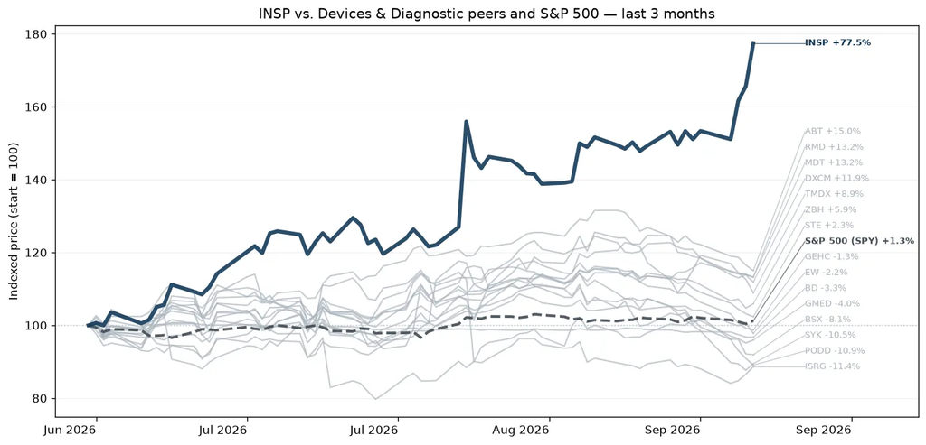

Inspire Medical Systems Inc operates as a medical technology company. It focuses on the development and commercialization of minimally invasive solutions for patients with obstructive sleep apnea (OSA). It offers Inspire system, a neurostimulation technology that provides a safe and effective treatment for moderate to severe obstructive sleep apnea. The firm has operating footprints in the United States and All other countries wherein, it generates a majority of its revenue from the United States. Its segment revenues are derived from the sales of its product, the Inspire system, to hospitals and ambulatory surgery centers in the U.S. and in selected countries in Europe and the Asia Pacific region.

### Eli Lilly (LLY)

*Big Pharma · $1.0T · 3m -1.5% · 12m +47.7% · 24m +20.8%*

[Google Finance](https://www.google.com/finance/quote/LLY:NYSE?tab=earnings&hl=en)

Obesity and diabetes powerhouse with GLP-1 franchise (Zepbound/Mounjaro) fueling growth.

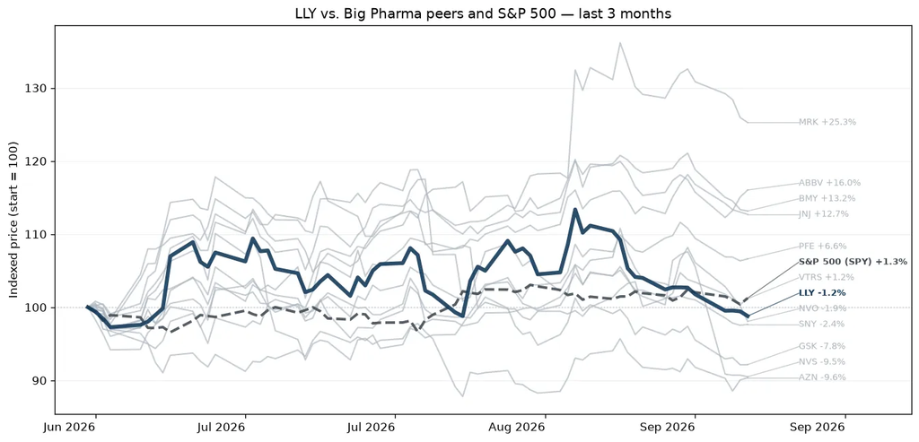

Eli Lilly is a drug firm with a focus on neuroscience, cardiometabolic, cancer, and immunology. Lilly's key products include Verzenio and Jaypirca for cancer; Mounjaro, Zepbound, Foundayo, Jardiance, Trulicity, Humalog, and Humulin for cardiometabolic; and Taltz and Olumiant for immunology.

### Novo Nordisk (NVO)

*Big Pharma · $195.8B · 3m -1.8% · 12m -21.5% · 24m -68.6%*

[Google Finance](https://www.google.com/finance/quote/NVO:NYSE?tab=earnings&hl=en)

Primary GLP-1 competitor to Lilly.

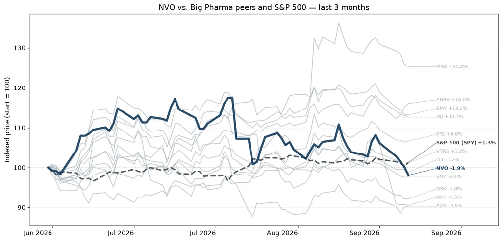

With roughly one-third of the global branded diabetes treatment market, Novo Nordisk is the leading provider of diabetes care products in the world. Based in Denmark, the company manufactures and markets a variety of human and modern insulins, injectable diabetes treatments such as GLP-1 therapy, oral antidiabetic agents, and obesity treatments. Novo also has a biopharmaceutical segment (contributing less than 10% of revenue) that specializes in protein therapies for hemophilia and other disorders.

### AbbVie (ABBV)

*Big Pharma · $430.8B · 3m +12.9% · 12m +17.8% · 24m +32.4%*

[Google Finance](https://www.google.com/finance/quote/ABBV:NYSE?tab=earnings&hl=en)

Immunology and aesthetics leader built around drugs like Skyrizi, Rinvoq, and Botox.

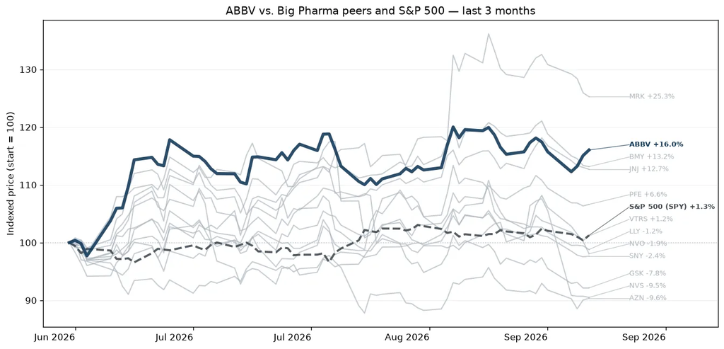

AbbVie is a pharmaceutical firm with a strong exposure to immunology (with Humira, Skyrizi, and Rinvoq) and oncology (with Imbruvica and Venclexta). The company was spun off from Abbott in early 2013. The 2020 acquisition of Allergan added several new products and drugs in aesthetics, including Botox. The 2024 acquisitions of Cerevel (neuroscience) and ImmunoGen (oncology) help supplement AbbVie's portfolio.

### Johnson & Johnson (JNJ)

*Big Pharma · $614.4B · 3m +10.3% · 12m +49.2% · 24m +60.5%*

[Google Finance](https://www.google.com/finance/quote/JNJ:NYSE?tab=earnings&hl=en)

Diversified healthcare giant, combining pharmaceuticals with medical devices.

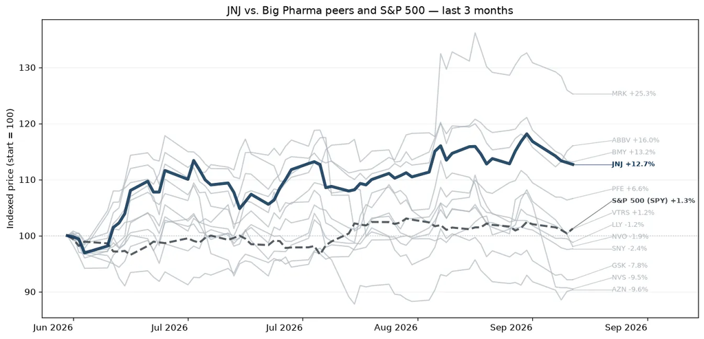

Johnson & Johnson is the world's largest and most diverse healthcare firm. It has two divisions: innovative medicine and medtech. These now represent all of the company's sales following the divestment of the consumer business, Kenvue, in 2023. After restructurings in 2023-24, the drug division focuses on three main therapeutic areas: immunology, oncology, and neurology. Geographically, just over half of total revenue is generated in the United States.

### Pfizer (PFE)

*Big Pharma · $144.8B · 3m +5.8% · 12m +16.1% · 24m -5.3%*

[Google Finance](https://www.google.com/finance/quote/PFE:NYSE?tab=earnings&hl=en)

Global pharma company known for vaccines and oncology.

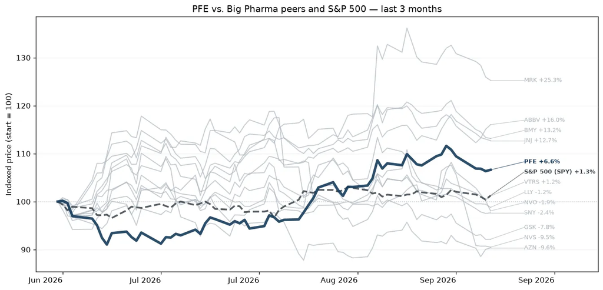

Pfizer is one of the world's largest pharmaceutical firms, with annual sales of roughly $60 billion. While it historically sold many types of healthcare products and chemicals, now prescription drugs and vaccines account for the majority of sales. Top sellers include pneumococcal vaccine Prevnar 13 and cardiology drugs Vyndaqel and Eliquis. Pfizer sells these products globally, with international sales representing 40% of total sales. Within international sales, emerging markets are a major contributor.

### Merck (MRK)

*Big Pharma · $316.1B · 3m +20.9% · 12m +73.8% · 24m +24.2%*

[Google Finance](https://www.google.com/finance/quote/MRK:NYSE?tab=earnings&hl=en)

Pharma leader driven by Keytruda, one of the world's most important cancer drugs.

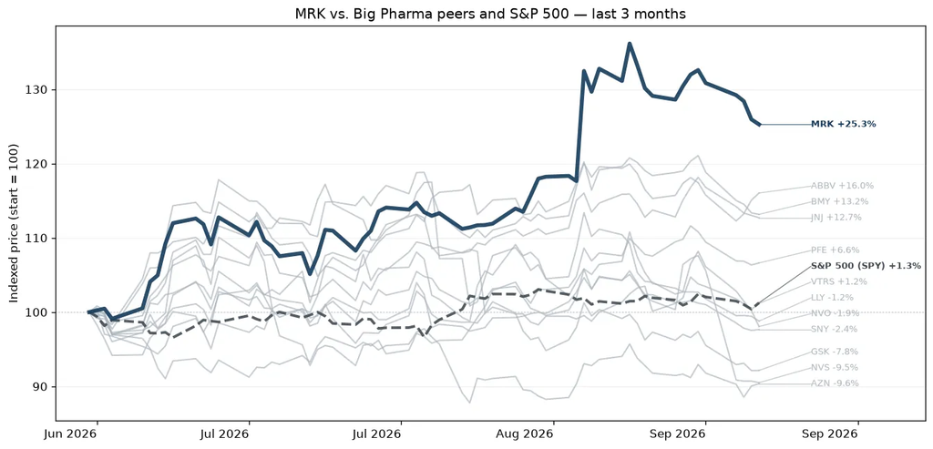

Merck makes pharmaceutical products to treat several conditions in a number of therapeutic areas, including cardiometabolic disease, cancer, and infections. Within cancer, the firm's immuno-oncology platform, led by Keytruda, is a major contributor to overall sales. The company also has a substantial vaccine business aimed at preventing pediatric diseases, as well as Gardasil for human papillomavirus. Additionally, Merck sells animal health-related drugs. From a geographical perspective, 47% of the company's sales are generated from US human health (pharmaceuticals and vaccines).

### Bristol Myers Squibb (BMY)

*Big Pharma · $134.6B · 3m +11.4% · 12m +37.7% · 24m +29.5%*

[Google Finance](https://www.google.com/finance/quote/BMY:NYSE?tab=earnings&hl=en)

Oncology and immunology specialist with a porfolio centered on cancer and cardiovascular medicines.

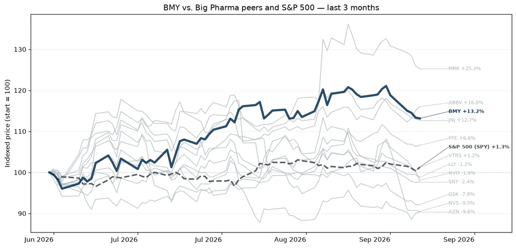

Bristol Myers Squibb discovers, develops, and markets drugs for various therapeutic areas, such as cardiovascular, cancer, and immune disorders. A key focus for Bristol is immuno-oncology, where the firm is a leader in drug development. Bristol derives close to 70% of total sales from the US, showing a higher dependence on the US market than most of its peer group.

### Viatris (VTRS)

*Big Pharma · $20.6B · 3m +0.2% · 12m +65.8% · 24m +41.6%*

[Google Finance](https://www.google.com/finance/quote/VTRS:NASDAQ?tab=earnings&hl=en)

Global generic and off-patent medicine company focused on scale manufacturing and cash generation, rather than breakthrough innovation.

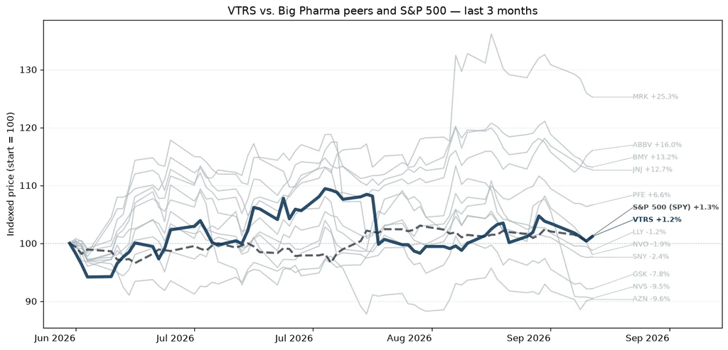

Viatris was formed in November 2020 through the combination of Upjohn, a wholly owned subsidiary of Pfizer that specialized in off-patent drugs, and Mylan, a global pharmaceutical manufacturer that focused on generic and specialty drugs. By joining forces, Viatris became one of the largest generic drug manufacturers in the world, servicing over 165 countries. Generics (commoditized and complex) and biosimilars make up roughly 40% of Viatris' total sales. The remaining 60% of sales are derived from its portfolio of legacy products, which includes Lipitor, Norvasc, Lyrica, and Viagra. While it covers more than 10 major therapeutic areas, Viatris has identified dermatology, ophthalmology, and gastroenterology as its three key areas of focus for future innovations.

### AstraZeneca (AZN)

*Big Pharma · $241.3B · 3m -10.4% · 12m +0.7% · 24m +2.3%*

[Google Finance](https://www.google.com/finance/quote/AZN:NYSE?tab=earnings&hl=en)

global pharmaceutical company with leading oncology, cardiovascular, and rare disease franchises.

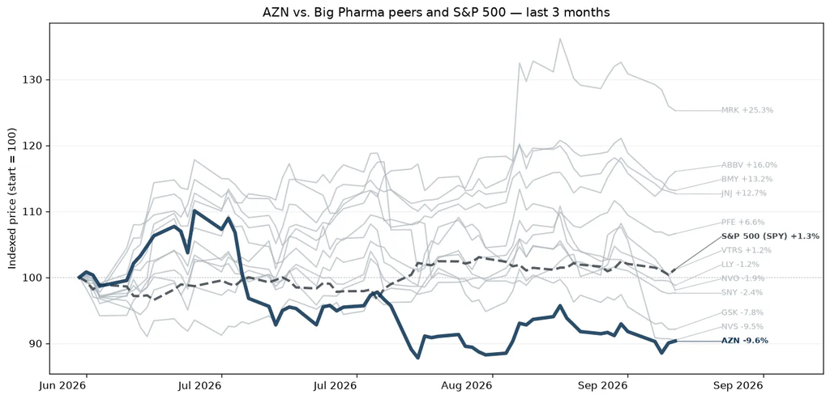

A merger between Astra of Sweden and Zeneca of the United Kingdom formed AstraZeneca in 1999. The firm sells branded drugs across a number of major therapeutic areas, including oncology (over 40% of total revenue), cardiovascular, renal, and metabolic (over 20%), rare disease (16%), and respiratory and immunology (15%). The majority of sales comes from international markets, with the United States representing close to one-third of its sales.

### Novartis (NVS)

*Big Pharma · $291.3B · 3m -10.4% · 12m +10.5% · 24m +18.6%*

[Google Finance](https://www.google.com/finance/quote/NVS:NYSE?tab=earnings&hl=en)

innovative pharmaceutical company focused on cardiovascular, immunology, neuroscience, and oncology therapies.

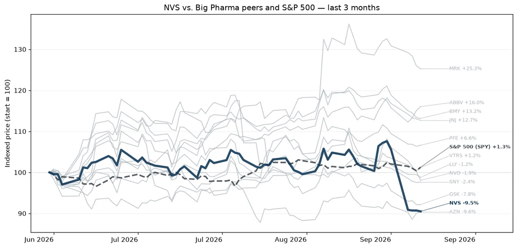

Novartis develops and manufactures innovative drugs. Key areas of drug development are oncology, immunology, neuroscience, respiratory, and cardiovascular, renal, and metabolic. It also has an established medicines business, which includes off-patent franchises. The company sells its products globally, with the United States constituting close to one-third of total revenue.

### Sanofi (SNY)

*Big Pharma · $103.6B · 3m -3.3% · 12m -9.1% · 24m -25.1%*

[Google Finance](https://www.google.com/finance/quote/SNY:NASDAQ?tab=earnings&hl=en)

diversified pharmaceutical company with strengths in vaccines, immunology, and rare diseases.

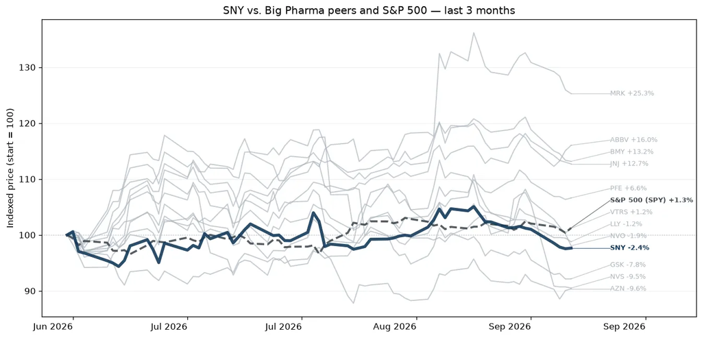

Sanofi develops and markets drugs with a concentration in immunology, vaccines, and rare diseases. Although the company offers a diverse array of drugs, its highest-revenue product, Dupixent, accounts for over 30% of total sales. Profits for this immunology blockbuster drug are shared with Regeneron. About 45% of total revenue comes from the United States, 20% from Europe, and 6% from China.

### GSK (GSK)

*Big Pharma · $103.2B · 3m -9.3% · 12m +17.9% · 24m +11.9%*

[Google Finance](https://www.google.com/finance/quote/GSK:NYSE?tab=earnings&hl=en)

pharmaceutical and vaccine company focused on infectious disease, respiratory, oncology, and specialty medicines.

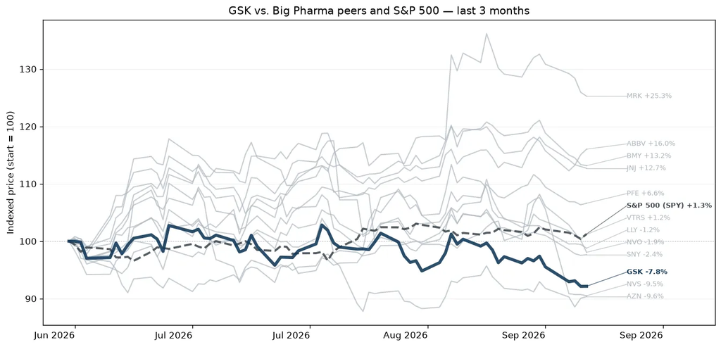

In the pharmaceutical industry, GSK ranks as one of the largest firms by total sales. The company wields its might across several therapeutic classes, including respiratory, antiviral, and vaccines, and has been growing its presence in oncology and immunology, as well. GSK uses joint ventures to gain additional scale in certain markets like HIV.

### Vertex (VRTX)

*Established Biotech · $121.3B · 3m +15.8% · 12m +30.6% · 24m +6.2%*

[Google Finance](https://www.google.com/finance/quote/VRTX:NASDAQ?tab=earnings&hl=en)

Dominant cystic fibrosis company expanding into gene editing, pain, and other specialty diseases.

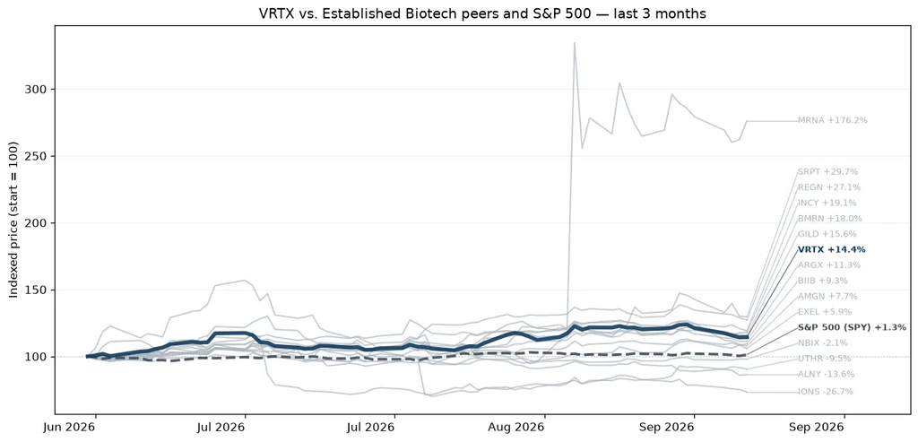

Vertex Pharmaceuticals is a global biotechnology company that discovers and develops small-molecule drugs for the treatment of serious diseases. Its key drugs are Kalydeco, Orkambi, Symdeko, and Trikafta/Kaftrio, and Alyftrek for cystic fibrosis, where Vertex therapies remain the standard of care globally. Vertex has diversified its portfolio through Casgevy, a gene-editing therapy for beta thalassemia and sickle-cell disease, and Journavx, a non-opioid pain medication approved for the treatment of moderate-to-severe acute pain in adults. Additionally, Vertex is evaluating small-molecule inhibitors of APOL1-mediated kidney diseases. Vertex is also investigating cell therapies to deliver a potential functional cure for type 1 diabetes.